# Lakes 2012 nars data

Water chemistry data (DOC, TN, and TP): 2 files for chemistry –> site data and actual chemistry data

`lakes2012_wc1 <- nars_data %>%` `filter(Survey == "Lakes 2012",` `Indicator == "Water Chemistry") %>%` `pull(filename) %>% '[[' (1) %>% # metadata` `paste0("../raw-data/", .) %>%` `read_csv()`

`lakes2012_wc2 <- nars_data %>%` `filter(Survey == "Lakes 2012",` `Indicator == "Water Chemistry") %>%` `pull(filename) %>% '[[' (2) %>% # chemistry data` `paste0("../raw-data/", .) %>%` `read_csv()`

lakes2012_wc1 = H<sub>2</sub>O chem metadata  
lakes2012_wc2 = H<sub>2</sub>O chem data

Grab the follow variables:

```r
lakevars <- c("UID", "SITE_ID", "DATE_COL", "DOC_RESULT", "DOC_QA_FLAG", "NTL_RESULT", "NTL_QA_FLAG", "PTL_RESULT", "PTL_QA_FLAG", "AGGR_ECO3_2015")
```

Create new CNP data frame: lakes2012_CNP

```r
lakes2012_meta <- dplyr::select(lakes2012_wc1, one_of(lakevars)) %>%
  unique()
lakes2012_data <- dplyr::select(lakes2012_wc2, one_of(lakevars))

lakes2012_CNP <- dplyr::inner_join(lakes2012_data, lakes2012_meta) %>%
  mutate(PTL_RESULT = PTL_RESULT/1000, #convert to mg/L
         C_mol = DOC_RESULT/12.011,
         N_mol = NTL_RESULT/14.007,
         P_mol = PTL_RESULT/30.974,
         CN_mol = (DOC_RESULT/NTL_RESULT)*(14.007/12.011),
         CP_mol = (DOC_RESULT/PTL_RESULT)*(30.974/12.011),
         NP_mol = (NTL_RESULT/PTL_RESULT)*(30.974/14.007))
```

Land cover data

Response variables

Summary plots of elemental concentration and stoichiometry

# DOC, TN, TP

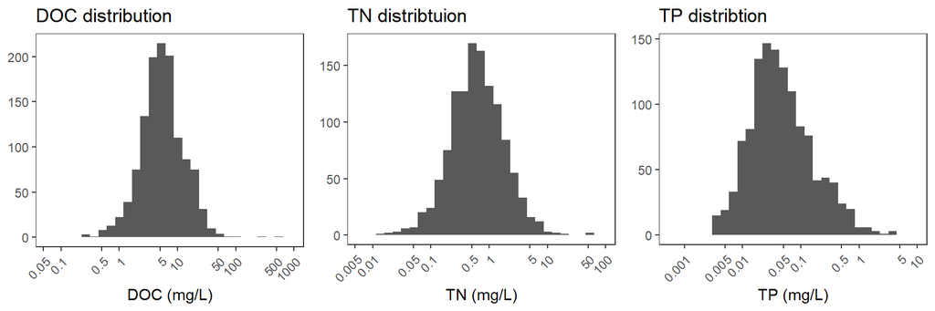

# CN, CP, NP

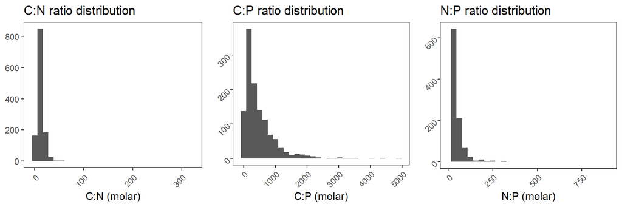

What is the distribution of collection dates?

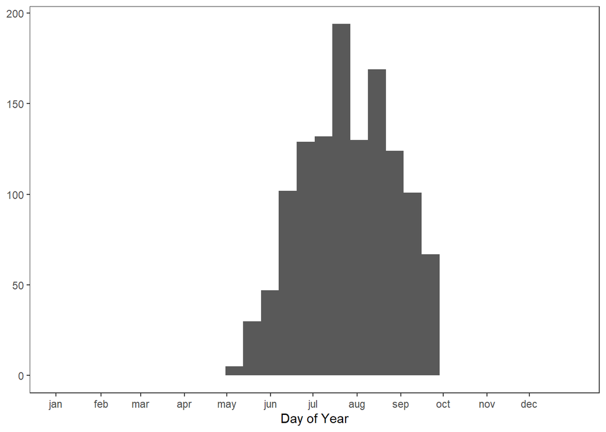

Bivariate elemental plots with stoichiometric isolines

```
##
## Call:
## lm(formula = log10(N_mol * 1000) ~ log10(P_mol * 1000), data = lakes2012_full)
##
## Residuals:
##      Min       1Q   Median       3Q      Max
## -1.66681 -0.16210  0.02057  0.18353  2.03994
##
## Coefficients:
##                     Estimate Std. Error t value Pr(>|t|)
## (Intercept)         1.537314   0.009396  163.62   <2e-16 ***
## log10(P_mol * 1000) 0.621350   0.016732   37.13   <2e-16 ***
## ---
## Signif. codes:  0 '***' 0.001 '**' 0.01 '*' 0.05 '.' 0.1 ' ' 1
##
## Residual standard error: 0.3119 on 1220 degrees of freedom
## Multiple R-squared:  0.5306, Adjusted R-squared:  0.5302
## F-statistic:  1379 on 1 and 1220 DF,  p-value: < 2.2e-16
```

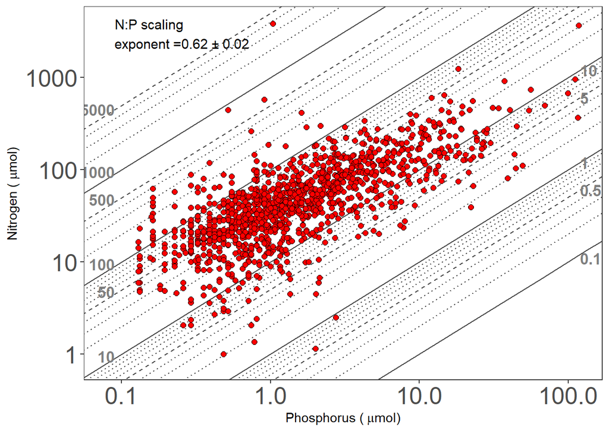